# Conditioning on a collider (a bit technical)

Macartan Humphreys

6/29/2020

# 1 Summary

[Knox, Lowe, and Mummolo](https://www.cambridge.org/core/journals/american-political-science-review/article/administrative-records-mask-racially-biased-policing/66BC0F9998543868BB20F241796B79B8) in an important study show how standard estimators underestimate discrimination when a set of plausible conditions hold. The study provides a textbook example of risks of bias that can arise from a common strategy for estimating discrimination. ([Here is a less technical note](https://macartan.github.io/i/notes/collider_estimands.html) that builds off [Bronner’s](https://fivethirtyeight.com/features/why-statistics-dont-capture-the-full-extent-of-the-systemic-bias-in-policing/) nice explainer with a walk through the intuition with a focus on collider bias.)

Since then:

- Gaebler et al provide a counterexample to [Knox, Lowe, and Mummolo](https://www.cambridge.org/core/journals/american-political-science-review/article/administrative-records-mask-racially-biased-policing/66BC0F9998543868BB20F241796B79B8) here: https://gist.github.com/jg43b/a5926fc98bf26cb157f4001d5a76f5a9
- Knox et al dismiss the counterexample as trickery. https://twitter.com/dean_c_knox/status/1276508890990075904
- I think there’s a bit more to it.

Here I “declare” a version of this counterexample, confirm that it is indeed a counterexample (and that there are more like it!) and dig a little into what is needed for this kind of counterexample. I agree with Knox et al that the example is indeed “knife edge” (in the sense that it holds for a parameter set that live on a plane in a cube) and so unlikely. But I still find it striking—and useful—to see that there are edges in which all “arrows” are strong but collider bias is weak. I know I at least had been thinking of the countercases as involving essentially removing arrows from the causal graph. Rather than dismissing the examples I think useful to assess the conditions under which collider bias is more or less of a concern.

# 2 The counterexample really is a counterexample with real causal relations between nodes

The example involves a situation in which there is a graph with a path of the form $D \rightarrow M \leftarrow U$ but for which $D$ is independent of $U$ when $M=1$. Specifically we have this causal graph involving $D$ (Race), $M$ (Being stopped), $U$ (Unobserved factor affecting stops and the use of force) and $Y$ (use of force).

```r
library(CausalQueries)
make_model("Y <- D -> M -> Y <- U; U ->M") %>% plot
```

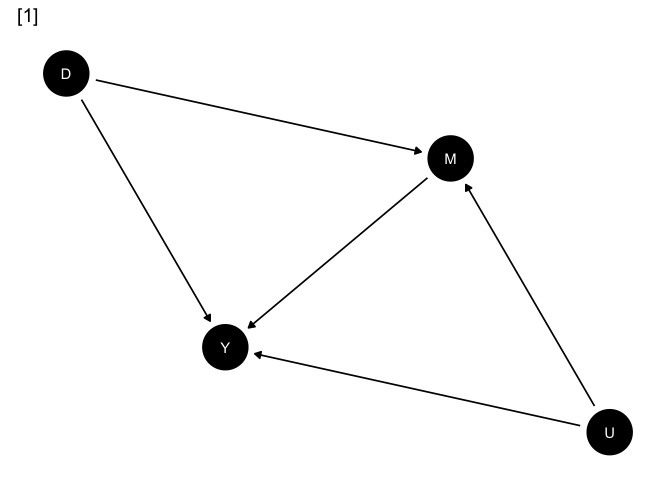

```r
knitr::include_graphics("https://macartan.github.io/assets/img/collider-independence-dag.jpg")
```

[output not shown]

I use DeclareDesign to declare the design and counterexample which lets us assess properties of the design quickly.

Declaration in this chunk:

```r
pr_D = .66  # Probability D = 1
pr_U = .45  # Probability U = 1
a <- 4      # A parameter

design <-

  declare_population(N = 10000,
                     D = rbinom(N, size = 1, prob = pr_D),
                     U = rbinom(N, size = 1, prob = pr_U)) +
  declare_potential_outcomes(M ~ rbinom(N, size = 1,  prob = (1+3*D)*(1+U)/8),
                             conditions = list(D = 0:1, U = 0:1)) +
  declare_reveal(outcome_variables = "M", assignment_variables = c("D", "U")) +
  declare_potential_outcomes(Y ~ M*rbinom(N, size = 1, prob = (1+D)*(1+U)/a),
                             conditions = list(D = 0:1)) +
  declare_reveal(outcome_variables = "Y",
                 assignment_variables = c("D")) +
  declare_estimand(CDE = mean((Y_D_1 - Y_D_0)[M==1])) +
  declare_estimator(Y ~ D, subset = M == 1, estimand = "CDE")
```

Sample data can be drawn from the design:

```r
df <- draw_data(design)
```

We see that the variables that should be correlated with each other are correlated with each other:

```r
df %>% select(D, M, U, Y) %>% cor %>% kable
```

|  | D | M | U | Y |
| --- | --- | --- | --- | --- |
| D | 1.0000000 | 0.5101216 | 0.0015718 | 0.4980726 |
| M | 0.5101216 | 1.0000000 | 0.3749769 | 0.7753171 |
| U | 0.0015718 | 0.3749769 | 1.0000000 | 0.5253109 |
| Y | 0.4980726 | 0.7753171 | 0.5253109 | 1.0000000 |

Here is the diagnosis:

```r
design %>%
  diagnose_design %>% reshape_diagnosis %>% kable(caption = "Diagnosis")
```

Diagnosis

| Design | Inquiry | Estimator | Outcome | Term | N Sims | Mean Estimand | Mean Estimate | Bias | SD Estimate | RMSE | Power | Coverage |
| --- | --- | --- | --- | --- | --- | --- | --- | --- | --- | --- | --- | --- |
| . | CDE | estimator | Y | D | 500 | 0.41 | 0.41 | 0.00 | 0.02 | 0.02 | 1.00 | 0.97 |
|  |  |  |  |  |  | (0.00) | (0.00) | (0.00) | (0.00) | (0.00) | (0.00) | (0.01) |

And here is the diagnosis of a perturbed design. Here I just change parameter `a` and diagnose again.

```r
design %>%
  redesign(a = 5) %>% diagnose_design %>% reshape_diagnosis %>% kable(caption = "A perturbation")
```

A perturbation

| Design | a | Inquiry | Estimator | Outcome | Term | N Sims | Mean Estimand | Mean Estimate | Bias | SD Estimate | RMSE | Power | Coverage |
| --- | --- | --- | --- | --- | --- | --- | --- | --- | --- | --- | --- | --- | --- |
| . | 5 | CDE | estimator | Y | D | 500 | 0.32 | 0.32 | -0.00 | 0.02 | 0.02 | 1.00 | 0.97 |
|  |  |  |  |  |  |  | (0.00) | (0.00) | (0.00) | (0.00) | (0.00) | (0.00) | (0.01) |

# 3 Why no collider bias?

We can see in the data that conditional independence seems to hold when $M=1$ despite $M$ being a collider:

```r
df %>% filter(M==1) %>% select(D, U) %>% cor
```

```
             D            U
D  1.000000000 -0.006540089
U -0.006540089  1.000000000
```

Though not when $M=0$.

```r
df %>% filter(M==0) %>% select(D, U) %>% cor
```

```
           D          U
D  1.0000000 -0.4586646
U -0.4586646  1.0000000
```

Why is that? Is the counterexample “generic”?

Pearl readers expect such exceptions to be rare, but let’s look more carefully to see why we get an exception here. Let’s say $p_{u,d,m}$ is the probability that $U=u, D=d$ and $M=m$. We are interested in whether $U$ and $D$ are independent given $M=1$. Now let’s ask in particular if $\Pr(U=1 | D=1, M=1)= \Pr(U=1 | D=0, M=1)$

Or:

$$\frac{p_{1,1,1}}{p_{1,1,1} + p_{0,1,1}}
= \frac{p_{1,0,1}}{p_{1,0,1} + p_{0,0,1}}$$

$$({p_{1,0,1} + p_{0,0,1}} ){p_{1,1,1}} =
({p_{1,1,1} + p_{0,1,1}}){p_{1,0,1}}$$
$${p_{0,0,1}} {p_{1,1,1}} =
{p_{0,1,1}}{p_{1,0,1}}$$
Note that given the graph, this does not depend on $\Pr(U=1)$ or $\Pr(D=1)$ but rather on whether:

$$\Pr(M=1 | U = 1, D=1)\Pr(M = 1 | U = 0,
D=0) = \Pr(M=1 | U = 1, D=0)\Pr(M = 1 | U = 0, D=1)$$

Thanks to the multiplicative function in the current example we indeed have:

$$\frac{(1+3)(1+1)}8 \frac{(1+0)(1+0)}8 =
\frac{(1+0)(1+1)}8 \frac{(1+3)(1+0)}8$$

The key thing here it that this condition poses a constraint on the relationship between these four probabilities. Intuitively, they have to live on a plane in a cube.

# 4 Some Takes

Some takes:

- One take: there are indeed cases in which there is no bias from colliders.
- Second take: yes but these are pathological.
- Third take: maybe, but they usefully remind us that there are possibly regions where bias is small.

To wit, a modification that moves us away from the knife edge but for which bias remains quite small:

```r
design_2 <- replace_step(design,step = 2,
                         declare_potential_outcomes(M ~ rbinom(N, size = 1,  prob = D/3 +(1+3*D)*(1+U)/12),
                             conditions = list(D = 0:1, U = 0:1)))
```

```r
df_2 <- draw_data(design_2)
df_2 %>% select(D, M, U, Y) %>% cor %>% kable
```

|  | D | M | U | Y |
| --- | --- | --- | --- | --- |
| D | 1.0000000 | 0.6540526 | 0.0106054 | 0.5531229 |
| M | 0.6540526 | 1.0000000 | 0.2722615 | 0.7531466 |
| U | 0.0106054 | 0.2722615 | 1.0000000 | 0.4795801 |
| Y | 0.5531229 | 0.7531466 | 0.4795801 | 1.0000000 |

```r
df_2 %>% filter(M==1) %>% select(D, U) %>% cor %>% kable(caption = "Collider bias (conditional correlation)")
```

Collider bias (conditional correlation)

|  | D | U |
| --- | --- | --- |
| D | 1.000000 | -0.035145 |
| U | -0.035145 | 1.000000 |

```r
design_2 %>%  diagnose_design %>% reshape_diagnosis %>% kable(caption = "Diagnosis: Another perturbation")
```

Diagnosis: Another perturbation

| Design | Inquiry | Estimator | Outcome | Term | N Sims | Mean Estimand | Mean Estimate | Bias | SD Estimate | RMSE | Power | Coverage |
| --- | --- | --- | --- | --- | --- | --- | --- | --- | --- | --- | --- | --- |
| . | CDE | estimator | Y | D | 500 | 0.39 | 0.37 | -0.02 | 0.02 | 0.03 | 1.00 | 0.89 |
|  |  |  |  |  |  | (0.00) | (0.00) | (0.00) | (0.00) | (0.00) | (0.00) | (0.01) |